# GitHub

Most recent datum: **Sep 19, 2026**Page built on Sep 19, 2026, 11:30 UTC. Every figure below is dated by its data, never by this build.

State of each curated repository, issue and pull-request activity, traffic since collection began, and commits as a secondary series.

ⓘ Aggregates per repository only. No issue title, no author, no e-mail address is collected or published.

## Repository state

Snapshot of Sep 19, 2026

| Repository | Open issues | Open PRs | Oldest open issue | Stars | Forks | Watchers | Last push | Archived |
| --- | --- | --- | --- | --- | --- | --- | --- | --- |
| evandeilton/betaregscale | 0 | 0 | none | 1 | 0 | 1 | Sep 15, 2026, 23:22 UTC | no |
| evandeilton/gkwdist | 0 | 0 | none | 1 | 0 | 0 | Sep 16, 2026, 21:43 UTC | no |
| evandeilton/gkwreg | 0 | 0 | none | 2 | 0 | 1 | Aug 23, 2026, 18:37 UTC | no |
| evandeilton/OptimalBinningWoE | 0 | 0 | none | 4 | 0 | 2 | Sep 4, 2026, 12:38 UTC | no |
| evandeilton/rnp | 1 | 0 | 2,746 days | 2 | 0 | 1 | Jun 22, 2026, 17:01 UTC | no |

## Age of the oldest open issue

Age, not count: an old open issue is a signal, a large backlog of fresh ones usually is not.

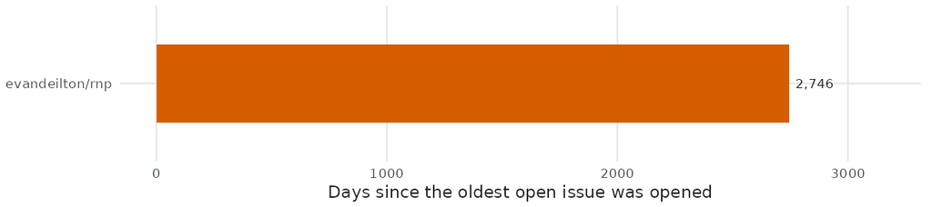

Chart data up to Sep 19, 2026.

## Issue and pull-request activity

Daily counts per repository. Merged and closed pull requests are disjoint: a merged pull request is counted only as merged.

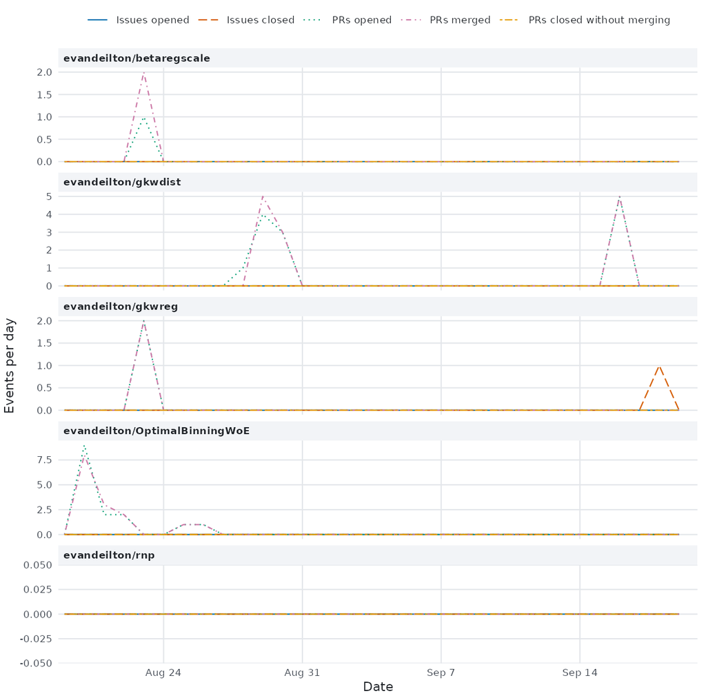

Chart data up to Sep 19, 2026.

## Traffic

Views and clones per repository. The GitHub traffic API retains fourteen days and nothing more, so this series is the only long-term copy of the data and it starts on the day collection began.

No traffic has been collected yet.

## Releases

Permanent table, newest first.

| Repository | Tag | Name | Published | Pre-release |
| --- | --- | --- | --- | --- |
| evandeilton/gkwdist | v1.1.6 | v1.1.6 — Base R contract, 25 correctness fixes, and a full documentation audit | Aug 30, 2026, 02:59 UTC | no |
| evandeilton/gkwreg | v2.1.18 | gkwreg 2.1.18 | Aug 23, 2026, 18:23 UTC | no |
| evandeilton/betaregscale | v2.7.4 | betaregscale 2.7.4 — vignette build time cut 5.3x for CRAN | Aug 23, 2026, 17:32 UTC | no |
| evandeilton/betaregscale | v2.7.3 | betaregscale 2.7.3 — interval likelihood conditioning, CRAN prep | Aug 23, 2026, 02:13 UTC | no |
| evandeilton/gkwreg | v2.1.17 | gkwreg 2.1.17 | Aug 23, 2026, 00:37 UTC | no |
| evandeilton/OptimalBinningWoE | v1.13.3 | v1.13.3 — Silent-answer audit: data loss, memory safety, ignored constraints, and a 1000× speedup | Aug 22, 2026, 23:20 UTC | no |
| evandeilton/OptimalBinningWoE | v1.13.2 | v1.13.2 — Audit fixes: silent scoring defects, behavior changes and CI hardening | Aug 20, 2026, 23:13 UTC | no |
| evandeilton/OptimalBinningWoE | v1.13.0 | v1.13.0 — `obwoe_scorecard()` the pipeline as one reviewable artefact | Aug 20, 2026, 12:26 UTC | no |
| evandeilton/OptimalBinningWoE | v1.11.0 | v1.11.0 — Runtime audit: crash, hang, data-loss and reproducibility fixes | Aug 12, 2026, 21:15 UTC | no |
| evandeilton/gkwdist | v1.1.5 | v1.1.5 — Numerical correctness fixes and componentwise derivative validation | Aug 11, 2026, 18:09 UTC | no |
| evandeilton/gkwdist | v1.1.4 | v1.1.4 — CRAN fix: skip timing-based tests on CRAN | May 27, 2026, 19:49 UTC | no |
| evandeilton/betaregscale | v2.7.1 | betaregscale v2.7.1 — Correctness & robustness audit | May 23, 2026, 19:08 UTC | no |
| evandeilton/gkwdist | v1.1.3 | v1.1.3 — Critical MLE Bug Fixes & Numerical Corrections | May 21, 2026, 00:35 UTC | no |
| evandeilton/OptimalBinningWoE | v1.10.0 | v1.10.0 — C++ Engine Audit & Hardening | May 17, 2026, 16:41 UTC | no |
| evandeilton/OptimalBinningWoE | v1.0.9 | OptimalBinningWoE 1.0.9 | Mar 14, 2026, 17:10 UTC | no |
| evandeilton/betaregscale | v2.7.0 | betaregscale 2.7.0 | Feb 28, 2026, 00:06 UTC | no |
| evandeilton/betaregscale | v2.6.9 | betaregscale 2.6.9 | Feb 21, 2026, 22:06 UTC | no |
| evandeilton/betaregscale | v2.6.8 | betaregscale 2.6.8 | Feb 21, 2026, 19:52 UTC | no |
| evandeilton/betaregscale | v2.6.7 | betaregscale v2.6.7 - CRAN Resubmission | Feb 20, 2026, 13:54 UTC | no |
| evandeilton/betaregscale | v2.6.6 | betaregscale 2.6.6 | Feb 18, 2026, 16:02 UTC | no |
| evandeilton/betaregscale | v2.6.5 | betaregscale 2.6.5 | Feb 18, 2026, 03:28 UTC | no |
| evandeilton/betaregscale | v2.6.3 | betaregscale 2.6.3 | Feb 17, 2026, 02:11 UTC | no |
| evandeilton/betaregscale | v2.6.1 | betaregscale 2.6.1 | Feb 16, 2026, 02:25 UTC | no |
| evandeilton/betaregscale | v2.6.0 | betaregscale 2.6.0 | Feb 15, 2026, 20:19 UTC | no |
| evandeilton/OptimalBinningWoE | v1.0.8 | OptimalBinningWoE 1.0.8 | Jan 29, 2026, 15:26 UTC | no |
| evandeilton/OptimalBinningWoE | v1.0.7 | OptimalBinningWoE 1.0.7 | Jan 28, 2026, 02:21 UTC | no |
| evandeilton/gkwreg | v2.1.16 | JOSS submission - Reviewed version [Zenodo] | Jan 18, 2026, 18:22 UTC | no |
| evandeilton/gkwreg | v2.1.15 | JOSS submission - reviewed version | Jan 18, 2026, 18:10 UTC | no |
| evandeilton/gkwreg | v2.1.14 | gkwreg 2.1.14 | Jan 8, 2026, 21:01 UTC | no |
| evandeilton/gkwdist | v1.1.2 | gkwdist 1.1.2 | Jan 8, 2026, 21:00 UTC | no |
| evandeilton/gkwreg | v2.1.5 | gkwreg 2.1.5 | Nov 27, 2025, 00:22 UTC | no |
| evandeilton/gkwdist | v1.1.1 | gkwdist 1.1.1 | Nov 26, 2025, 23:18 UTC | no |
| evandeilton/gkwreg | v2.1.4 | gkwreg 2.1.4 | Nov 16, 2025, 14:42 UTC | no |
| evandeilton/gkwdist | v1.0.10 | gkwdist 1.0.10 | Nov 16, 2025, 14:35 UTC | no |

## Commits, secondary series

Published here and nowhere else, deliberately. Raw commit volume is subject to Goodhart’s law: it measures typing, not production. It is shown as one series among others, never as a headline figure, and the dashboard sets no target and tracks no streak.

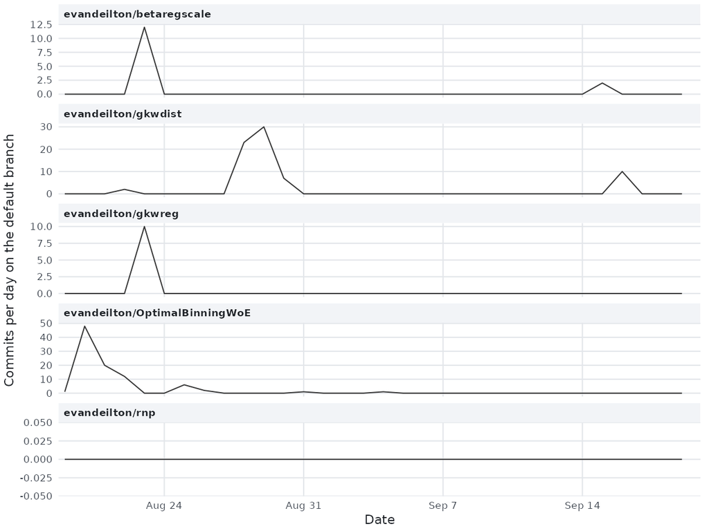

Chart data up to Sep 19, 2026.